# World Population Trend and CO2 Emission

Mutangana cyprien

`2026-11-06`

# 1 4.1 Load the datasets

```r
population <- read_csv("world_population.csv", show_col_types=FALSE)
co2_raw <- read_csv("CO2_emission.csv", show_col_types=FALSE,
                    name_repair="minimal")

# The supplied CO2 file contains two identical 2019 columns.
# Keep the first column for each duplicated header.
co2 <- co2_raw[, !duplicated(names(co2_raw))]

glimpse(population)
```

```
## Rows: 234
## Columns: 17
## $ Rank                          <dbl> 36, 138, 34, 213, 203, 42, 224, 201, 33,…
## $ CCA3                          <chr> "AFG", "ALB", "DZA", "ASM", "AND", "AGO"…
## $ `Country/Territory`           <chr> "Afghanistan", "Albania", "Algeria", "Am…
## $ Capital                       <chr> "Kabul", "Tirana", "Algiers", "Pago Pago…
## $ Continent                     <chr> "Asia", "Europe", "Africa", "Oceania", "…
## $ `2022 Population`             <dbl> 41128771, 2842321, 44903225, 44273, 7982…
## $ `2020 Population`             <dbl> 38972230, 2866849, 43451666, 46189, 7770…
## $ `2015 Population`             <dbl> 33753499, 2882481, 39543154, 51368, 7174…
## $ `2010 Population`             <dbl> 28189672, 2913399, 35856344, 54849, 7151…
## $ `2000 Population`             <dbl> 19542982, 3182021, 30774621, 58230, 6609…
## $ `1990 Population`             <dbl> 10694796, 3295066, 25518074, 47818, 5356…
## $ `1980 Population`             <dbl> 12486631, 2941651, 18739378, 32886, 3561…
## $ `1970 Population`             <dbl> 10752971, 2324731, 13795915, 27075, 1986…
## $ `Area (km²)`                  <dbl> 652230, 28748, 2381741, 199, 468, 124670…
## $ `Density (per km²)`           <dbl> 63.0587, 98.8702, 18.8531, 222.4774, 170…
## $ `Growth Rate`                 <dbl> 1.0257, 0.9957, 1.0164, 0.9831, 1.0100, …
## $ `World Population Percentage` <dbl> 0.52, 0.04, 0.56, 0.00, 0.00, 0.45, 0.00…
```

```r
glimpse(co2)
```

```
## Rows: 215
## Columns: 34
## $ `Country Name`   <chr> "Aruba", "Afghanistan", "Angola", "Albania", "Andorra…
## $ country_code     <chr> "ABW", "AFG", "AGO", "ALB", "AND", "ARE", "ARG", "ARM…
## $ Region           <chr> "Latin America & Caribbean", "South Asia", "Sub-Sahar…
## $ `Indicator Name` <chr> "CO2 emissions (metric tons per capita)", "CO2 emissi…
## $ `1990`           <dbl> NA, 0.19174511, 0.55366196, 1.81954163, 7.52183166, 3…
## $ `1991`           <dbl> NA, 0.16768158, 0.54453865, 1.24281022, 7.23537924, 3…
## $ `1992`           <dbl> NA, 0.09595774, 0.54355722, 0.68369983, 6.96307870, 2…
## $ `1993`           <dbl> NA, 0.08472111, 0.70898423, 0.63830704, 6.72417752, 2…
## $ `1994`           <dbl> NA, 0.07554583, 0.83680440, 0.64535519, 6.54157891, 3…
## $ `1995`           <dbl> NA, 0.06846796, 0.91214149, 0.60543625, 6.73347949, 3…
## $ `1996`           <dbl> NA, 0.06258803, 1.07216847, 0.61236736, 6.99159455, 3…
## $ `1997`           <dbl> NA, 0.05682662, 1.08663697, 0.46692147, 7.30744115, 3…
## $ `1998`           <dbl> NA, 0.05269086, 1.09182531, 0.57215370, 7.63953851, 2…
```

[output cut: 21 more lines]

# 2 4.2 Exploratory data analysis

## 2.1 Population dataset structure

```r
cat("\n1. VARIABLE NAMES\n")
```

```
##
## 1. VARIABLE NAMES
```

```r
names(population)
```

```
##  [1] "Rank"                        "CCA3"
##  [3] "Country/Territory"           "Capital"
##  [5] "Continent"                   "2022 Population"
##  [7] "2020 Population"             "2015 Population"
##  [9] "2010 Population"             "2000 Population"
## [11] "1990 Population"             "1980 Population"
## [13] "1970 Population"             "Area (km²)"
## [15] "Density (per km²)"           "Growth Rate"
## [17] "World Population Percentage"
```

```r
cat("\n2. FIRST 5 ROWS\n")
```

```
##
## 2. FIRST 5 ROWS
```

```r
head(population, 5)
```

```
## # A tibble: 5 × 17
##    Rank CCA3  `Country/Territory` Capital          Continent `2022 Population`
##   <dbl> <chr> <chr>               <chr>            <chr>                 <dbl>
## 1    36 AFG   Afghanistan         Kabul            Asia               41128771
## 2   138 ALB   Albania             Tirana           Europe              2842321
## 3    34 DZA   Algeria             Algiers          Africa             44903225
## 4   213 ASM   American Samoa      Pago Pago        Oceania               44273
## 5   203 AND   Andorra             Andorra la Vella Europe                79824
## # ℹ 11 more variables: `2020 Population` <dbl>, `2015 Population` <dbl>,
## #   `2010 Population` <dbl>, `2000 Population` <dbl>, `1990 Population` <dbl>,
## #   `1980 Population` <dbl>, `1970 Population` <dbl>, `Area (km²)` <dbl>,
## #   `Density (per km²)` <dbl>, `Growth Rate` <dbl>,
## #   `World Population Percentage` <dbl>
```

```r
cat("\n3. LAST 10 ROWS\n")
```

```
##
## 3. LAST 10 ROWS
```

```r
tail(population, 10)
```

```
## # A tibble: 10 × 17
##     Rank CCA3  `Country/Territory` Capital      Continent     `2022 Population`
##    <dbl> <chr> <chr>               <chr>        <chr>                     <dbl>
##  1    43 UZB   Uzbekistan          Tashkent     Asia                   34627652
##  2   181 VUT   Vanuatu             Port-Vila    Oceania                  326740
##  3   234 VAT   Vatican City        Vatican City Europe                      510
##  4    51 VEN   Venezuela           Caracas      South America          28301696
##  5    16 VNM   Vietnam             Hanoi        Asia                   98186856
##  6   226 WLF   Wallis and Futuna   Mata-Utu     Oceania                   11572
##  7   172 ESH   Western Sahara      El Aaiún     Africa                   575986
##  8    46 YEM   Yemen               Sanaa        Asia                   33696614
##  9    63 ZMB   Zambia              Lusaka       Africa                 20017675
## 10    74 ZWE   Zimbabwe            Harare       Africa                 16320537
## # ℹ 11 more variables: `2020 Population` <dbl>, `2015 Population` <dbl>,
## #   `2010 Population` <dbl>, `2000 Population` <dbl>, `1990 Population` <dbl>,
## #   `1980 Population` <dbl>, `1970 Population` <dbl>, `Area (km²)` <dbl>,
## #   `Density (per km²)` <dbl>, `Growth Rate` <dbl>,
## #   `World Population Percentage` <dbl>
```

```r
cat("\n4. DATA TYPES AND STRUCTURE\n")
```

```
##
## 4. DATA TYPES AND STRUCTURE
```

```r
str(population)
```

```
## spc_tbl_ [234 × 17] (S3: spec_tbl_df/tbl_df/tbl/data.frame)
##  $ Rank                       : num [1:234] 36 138 34 213 203 42 224 201 33 140 ...
##  $ CCA3                       : chr [1:234] "AFG" "ALB" "DZA" "ASM" ...
##  $ Country/Territory          : chr [1:234] "Afghanistan" "Albania" "Algeria" "American Samoa" ...
##  $ Capital                    : chr [1:234] "Kabul" "Tirana" "Algiers" "Pago Pago" ...
##  $ Continent                  : chr [1:234] "Asia" "Europe" "Africa" "Oceania" ...
##  $ 2022 Population            : num [1:234] 41128771 2842321 44903225 44273 79824 ...
##  $ 2020 Population            : num [1:234] 38972230 2866849 43451666 46189 77700 ...
##  $ 2015 Population            : num [1:234] 33753499 2882481 39543154 51368 71746 ...
##  $ 2010 Population            : num [1:234] 28189672 2913399 35856344 54849 71519 ...
##  $ 2000 Population            : num [1:234] 19542982 3182021 30774621 58230 66097 ...
##  $ 1990 Population            : num [1:234] 10694796 3295066 25518074 47818 53569 ...
##  $ 1980 Population            : num [1:234] 12486631 2941651 18739378 32886 35611 ...
##  $ 1970 Population            : num [1:234] 10752971 2324731 13795915 27075 19860 ...
##  $ Area (km²)                 : num [1:234] 652230 28748 2381741 199 468 ...
##  $ Density (per km²)          : num [1:234] 63.1 98.9 18.9 222.5 170.6 ...
##  $ Growth Rate                : num [1:234] 1.026 0.996 1.016 0.983 1.01 ...
##  $ World Population Percentage: num [1:234] 0.52 0.04 0.56 0 0 0.45 0 0 0.57 0.03 ...
##  - attr(*, "spec")=
##   .. cols(
##   ..   Rank = col_double(),
##   ..   CCA3 = col_character(),
##   ..   `Country/Territory` = col_character(),
##   ..   Capital = col_character(),
##   ..   Continent = col_character(),
##   ..   `2022 Population` = col_double(),
##   ..   `2020 Population` = col_double(),
##   ..   `2015 Population` = col_double(),
##   ..   `2010 Population` = col_double(),
##   ..   `2000 Population` = col_double(),
##   ..   `1990 Population` = col_double(),
##   ..   `1980 Population` = col_double(),
##   ..   `1970 Population` = col_double(),
##   ..   `Area (km²)` = col_double(),
##   ..   `Density (per km²)` = col_double(),
##   ..   `Growth Rate` = col_double(),
##   ..   `World Population Percentage` = col_double()
##   .. )
##  - attr(*, "problems")=<pointer: 0x0000020e493fff70>
```

```r
cat("\n5. DATASET DIMENSIONS\n")
```

```
##
## 5. DATASET DIMENSIONS
```

```r
dim(population)
```

```
## [1] 234  17
```

```r
cat("\nNumber of rows:", nrow(population))
```

```
##
## Number of rows: 234
```

```r
cat("\nNumber of columns:", ncol(population), "\n")
```

```
##
## Number of columns: 17
```

## 2.2 Duplicates and missing values

```r
cat("\n==========================================\n")
cat("       DUPLICATE AND MISSING VALUES\n")
```

```
##        DUPLICATE AND MISSING VALUES
```

```r
cat("==========================================\n\n")
cat("1. NUMBER OF DUPLICATE ROWS:\n")
```

```
## 1. NUMBER OF DUPLICATE ROWS:
```

```r
sum(duplicated(population))
```

```
## [1] 0
```

```r
population <- distinct(population)
cat("\n2. MISSING VALUES IN EACH COLUMN:\n")
```

```
##
## 2. MISSING VALUES IN EACH COLUMN:
```

```r
colSums(is.na(population))
```

```
##                        Rank                        CCA3
##                           0                           0
##           Country/Territory                     Capital
##                           0                           0
##                   Continent             2022 Population
##                           0                           0
##             2020 Population             2015 Population
##                           0                           0
##             2010 Population             2000 Population
##                           0                           0
##             1990 Population             1980 Population
##                           0                           0
##             1970 Population                  Area (km²)
##                           0                           0
##           Density (per km²)                 Growth Rate
##                           0                           0
## World Population Percentage
##                           0
```

## 2.3 Missing values in CO2 data

```r
colSums(is.na(co2))
```

```
##   Country Name   country_code         Region Indicator Name           1990
##              0              0              0              0             30
##           1991           1992           1993           1994           1995
##             29             26             26             26             25
##           1996           1997           1998           1999           2000
##             25             25             26             26             25
##           2001           2002           2003           2004           2005
##             25             24             24             24             24
##           2006           2007           2008           2009           2010
##             24             24             24             24             24
##           2011           2012           2013           2014           2015
##             24             24             24             24             24
##           2016           2017           2018           2019
##             24             24             24             24
```

## 2.4 Outlier detection using boxplots

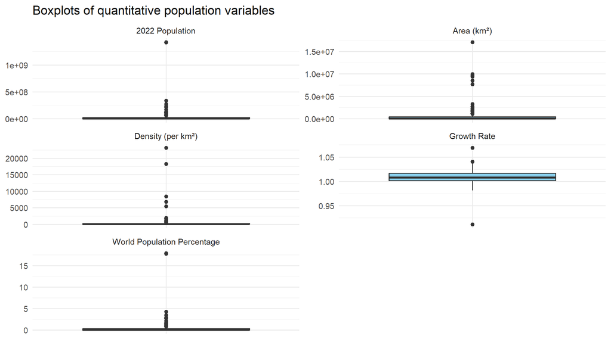

```r
quant_vars <- population %>%
  select(`2022 Population`, `Area (km²)`, `Density (per km²)`,
         `Growth Rate`, `World Population Percentage`)

quant_vars %>%
  pivot_longer(everything(), names_to="Variable", values_to="Value") %>%
  ggplot(aes(x=Variable, y=Value)) +
  geom_boxplot(fill="skyblue") +
  facet_wrap(~Variable, scales="free", ncol=2) +
  labs(title="Boxplots of quantitative population variables", x=NULL, y=NULL) +
  theme_minimal() +
  theme(axis.text.x=element_blank(), axis.ticks.x=element_blank())
```

The boxplots flag statistical extremes, not necessarily errors. Country area, population and density differ greatly by country, so legitimate extreme observations are retained. The data are not winsorized or deleted without evidence of an error.

# 3 4.3 Predict population in 2030

The dataset’s `Growth Rate` values are annual growth factors (for example, 1.0257 means approximately 2.57% growth), rather than decimal rates. Therefore, the assignment equation “(N_t=P e^{rt})” is implemented as “(N_{2030}=P times g^8)”, equivalently using (r=log(g)), where (g) is the supplied growth factor.

```r
population <- population %>%
  mutate(Predicted_2030 = `2022 Population` *(`Growth Rate` ^ 8))

population %>%
  select(`Country/Territory`, `2022 Population`, `Growth Rate`,
         Predicted_2030) %>%
  arrange(desc(Predicted_2030)) %>%
  print(n=20)
```

```
## # A tibble: 234 × 4
##    `Country/Territory` `2022 Population` `Growth Rate` Predicted_2030
##    <chr>                           <dbl>         <dbl>          <dbl>
##  1 India                      1417173173         1.01     1496127403.
##  2 China                      1425887337         1        1425887337
##  3 United States               338289857         1.00      348711690.
##  4 Indonesia                   275501339         1.01      289927051.
##  5 Pakistan                    235824862         1.02      274362026.
##  6 Nigeria                     218541212         1.02      264406591.
##  7 Brazil                      215313498         1.00      223365784.
##  8 Bangladesh                  171186372         1.01      186548196.
##  9 Ethiopia                    123379924         1.03      151149718.
## 10 Russia                      144713314         0.997     141616886.
## 11 Mexico                      127504125         1.01      134073830.
## 12 Philippines                 115559009         1.01      129868879.
## 13 DR Congo                     99010212         1.03      127879366.
## 14 Egypt                       110990103         1.02      125820070.
## 15 Japan                       123951692         0.995     118792604.
## 16 Vietnam                      98186856         1.01      104152315.
## 17 Iran                         88550570         1.01       93707020.
## 18 Turkey                       85341241         1.01       90024248.
## 19 Germany                      83369843         1.000      83036947.
## 20 Tanzania                     65497748         1.03       82970588.
## # ℹ 214 more rows
```

```r
write_csv(population, "population_with_2030_projection.csv")
```

# 4 4.4 Extract values and plot trends

## 4.1 Top 10 countries by 2022 population

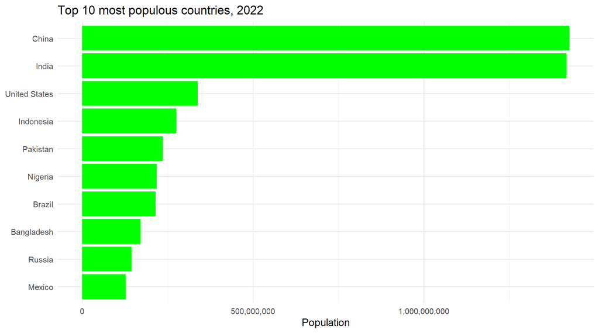

```r
top10 <- population %>%
  slice_max(order_by=`2022 Population`, n=10, with_ties=FALSE) %>%
  arrange(desc(`2022 Population`))

top10 %>%
  mutate(`Country/Territory`=fct_reorder(`Country/Territory`,
                                        `2022 Population`)) %>%
  ggplot(aes(x=`Country/Territory`, y=`2022 Population`)) +
  geom_col(fill="green") +
  coord_flip() +
  scale_y_continuous(labels=scales::comma) +
  labs(title="Top 10 most populous countries, 2022",
       x=NULL, y="Population") +
  theme_minimal()
```

## 4.2 Population trend from 1990 to 2022

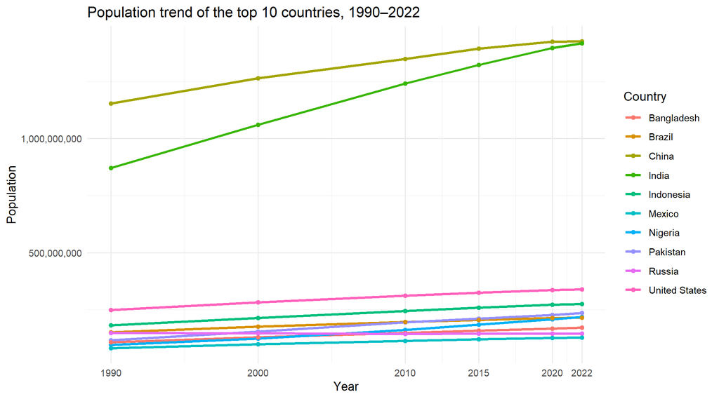

```r
pop_trend <- top10 %>%
  select(`Country/Territory`, `1990 Population`, `2000 Population`,
         `2010 Population`, `2015 Population`, `2020 Population`,
         `2022 Population`) %>%
  pivot_longer(-`Country/Territory`, names_to="Year", values_to="Population") %>%
  mutate(Year=as.integer(str_extract(Year, "[0-9]{4}")))

ggplot(pop_trend, aes(Year, Population, colour=`Country/Territory`)) +
  geom_line(linewidth=1) + geom_point() +
  scale_y_continuous(labels=scales::comma) +
  scale_x_continuous(breaks=c(1990,2000,2010,2015,2020,2022)) +
  labs(title="Population trend of the top 10 countries, 1990–2022",
       x="Year", y="Population", colour="Country") +
  theme_minimal()
```

## 4.3 CO2 emission trend for the same top 10 countries

The CO2 indicator in the supplied file is **CO2 emissions (metric tons per capita)**. Missing country-year observations remain missing and are not treated as zero.

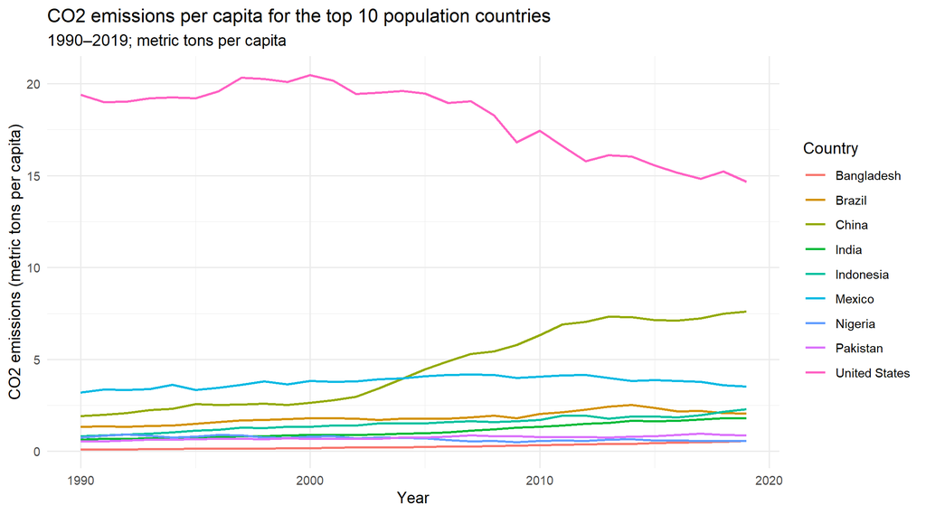

```r
co2_top <- co2 %>%
  filter(`Country Name` %in% top10$`Country/Territory`) %>%
  select(`Country Name`, all_of(as.character(1990:2019))) %>%
  pivot_longer(-`Country Name`, names_to="Year", values_to="CO2_per_capita") %>%
  mutate(Year=as.integer(Year))

ggplot(co2_top, aes(Year, CO2_per_capita, colour=`Country Name`)) +
  geom_line(linewidth=0.8, na.rm=TRUE) +
  labs(title="CO2 emissions per capita for the top 10 population countries",
       subtitle="1990–2019; metric tons per capita",
       x="Year", y="CO2 emissions (metric tons per capita)",
       colour="Country") +
  theme_minimal()
```

# 5 4.5 Correlation analysis

## 5.1 Correlations among population variables

```r
corr_data <- population %>%
  select(`Area (km²)`, `Density (per km²)`, `Growth Rate`,
         `World Population Percentage`)

cor_matrix <- cor(corr_data, use="pairwise.complete.obs", method="pearson")
round(cor_matrix, 4)
```

```
##                             Area (km²) Density (per km²) Growth Rate
## Area (km²)                      1.0000           -0.0631     -0.0140
## Density (per km²)              -0.0631            1.0000     -0.0698
## Growth Rate                    -0.0140           -0.0698      1.0000
## World Population Percentage     0.4533           -0.0276     -0.0209
##                             World Population Percentage
## Area (km²)                                       0.4533
## Density (per km²)                               -0.0276
## Growth Rate                                     -0.0209
## World Population Percentage                      1.0000
```

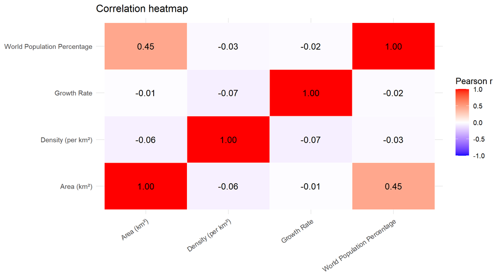

```r
cor_long <- as.data.frame(as.table(cor_matrix))
names(cor_long) <- c("Variable1", "Variable2", "Correlation")
ggplot(cor_long, aes(Variable1, Variable2, fill=Correlation)) +
  geom_tile(color="white") +
  geom_text(aes(label=sprintf("%.2f", Correlation)), size=4) +
  scale_fill_gradient2(low="blue", mid="white", high="red",
                       midpoint=0, limits=c(-1,1)) +
  labs(title="Correlation heatmap", x=NULL, y=NULL, fill="Pearson r") +
  theme_minimal() +
  theme(axis.text.x=element_text(angle=35, hjust=1))
```

## 5.2 Merge population and CO2 data; relationship analysis

```r
merged <- population %>%
  select(`Country/Territory`, Continent, `2022 Population`) %>%
  inner_join(co2 %>% select(`Country Name`, `2019`),
             by=c("Country/Territory"="Country Name")) %>%
  rename(CO2_2019_per_capita=`2019`) %>%
  filter(!is.na(`2022 Population`), !is.na(CO2_2019_per_capita))

dim(merged)
```

```
## [1] 168   4
```

```r
summary(merged)
```

```
##  Country/Territory     Continent   2022 Population     CO2_2019_per_capita
##  Length   :168     Length   :168   Min.   :1.131e+04   Min.   : 0.04468
##  N.unique :168     N.unique :  6   1st Qu.:2.368e+06   1st Qu.: 0.78542
##  N.blank  :  0     N.blank  :  0   Median :9.488e+06   Median : 2.89605
##  Min.nchar:  4     Min.nchar:  4   Mean   :4.273e+07   Mean   : 4.11549
##  Max.nchar: 24     Max.nchar: 13   3rd Qu.:2.985e+07   3rd Qu.: 5.57965
##                                    Max.   :1.426e+09   Max.   :32.47447
```

```r
cor(merged$`2022 Population`, merged$CO2_2019_per_capita,
    method="pearson")
```

```
## [1] 0.008170163
```

```r
cor.test(merged$`2022 Population`, merged$CO2_2019_per_capita,
         method="pearson")
```

```
##
##  Pearson's product-moment correlation
##
## data:  merged$`2022 Population` and merged$CO2_2019_per_capita
## t = 0.10527, df = 166, p-value = 0.9163
## alternative hypothesis: true correlation is not equal to 0
## 95 percent confidence interval:
##  -0.1434170  0.1593828
## sample estimates:
##         cor
## 0.008170163
```

```r
cor.test(merged$`2022 Population`, merged$CO2_2019_per_capita,
         method="spearman", exact=FALSE)
```

```
##
##  Spearman's rank correlation rho
##
## data:  merged$`2022 Population` and merged$CO2_2019_per_capita
## S = 891144, p-value = 0.09908
## alternative hypothesis: true rho is not equal to 0
## sample estimates:
##        rho
## -0.1276821
```

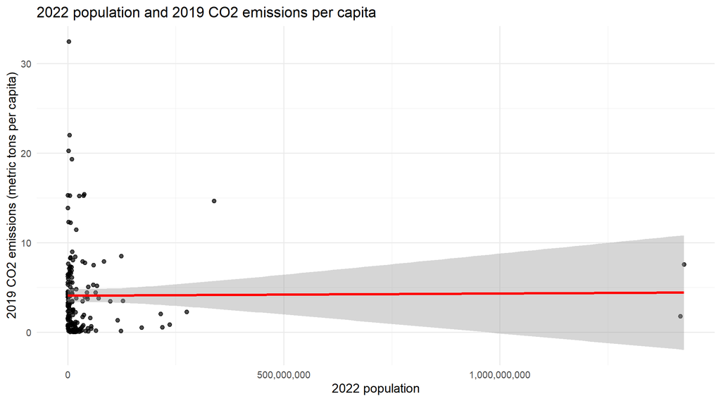

```r
ggplot(merged, aes(`2022 Population`, CO2_2019_per_capita)) +
  geom_point(alpha=0.7) +
  geom_smooth(method="lm", se=TRUE, colour="red") +
  scale_x_continuous(labels=scales::comma) +
  labs(title="2022 population and 2019 CO2 emissions per capita",
       x="2022 population", y="2019 CO2 emissions (metric tons per capita)") +
  theme_minimal()
```

```r
model <- lm(CO2_2019_per_capita ~ `2022 Population`, data=merged)
summary(model)
```

```
##
## Call:
## lm(formula = CO2_2019_per_capita ~ `2022 Population`, data = merged)
##
## Residuals:
##    Min     1Q Median     3Q    Max
## -4.065 -3.326 -1.209  1.474 28.369
##
## Coefficients:
##                    Estimate Std. Error t value Pr(>|t|)
## (Intercept)       4.105e+00  3.835e-01  10.703   <2e-16 ***
## `2022 Population` 2.449e-10  2.327e-09   0.105    0.916
## ---
## Signif. codes:  0 '***' 0.001 '**' 0.01 '*' 0.05 '.' 0.1 ' ' 1
##
## Residual standard error: 4.801 on 166 degrees of freedom
## Multiple R-squared:  6.675e-05,  Adjusted R-squared:  -0.005957
## F-statistic: 0.01108 on 1 and 166 DF,  p-value: 0.9163
```

# 6 4.6 Compare CO2 emissions across continents

The CO2 file reports a **per-capita** indicator and does not provide total national emissions. Following the assignment’s instruction to sum the available 2019 values, the code below sums country-level per-capita values by continent. These sums are comparative sums of per-capita indicators, not true continental total emissions. The mean is also reported to give a more interpretable per-country comparison.

```r
continent_co2 <- merged %>%
  group_by(Continent) %>%
  summarise(
    Sum_2019_per_capita_values=sum(CO2_2019_per_capita, na.rm=TRUE),
    Mean_2019_per_capita=mean(CO2_2019_per_capita, na.rm=TRUE),
    Countries=n(),
    .groups="drop"
  ) %>%
  arrange(desc(Sum_2019_per_capita_values))

continent_co2
```

```
## # A tibble: 6 × 4
##   Continent     Sum_2019_per_capita_values Mean_2019_per_capita Countries
##   <chr>                              <dbl>                <dbl>     <int>
## 1 Asia                               242.                  6.54        37
## 2 Europe                             229.                  5.73        40
## 3 North America                       79.6                 4.19        19
## 4 Africa                              58.0                 1.21        48
## 5 Oceania                             53.2                 4.09        13
## 6 South America                       29.4                 2.67        11
```

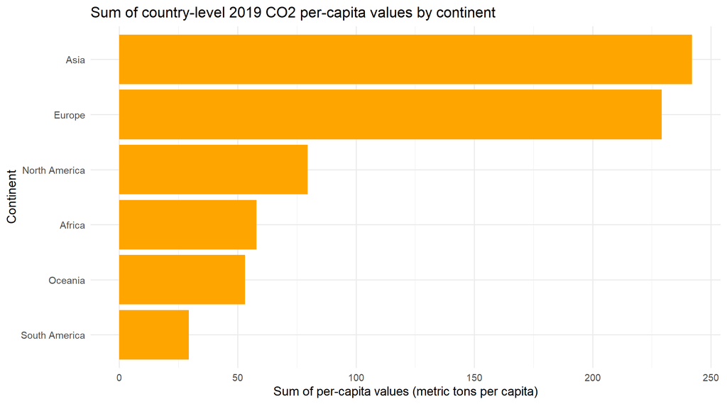

```r
ggplot(continent_co2,
       aes(x=reorder(Continent, Sum_2019_per_capita_values),
           y=Sum_2019_per_capita_values)) +
  geom_col(fill="orange") +
  coord_flip() +
  labs(title="Sum of country-level 2019 CO2 per-capita values by continent",
       x="Continent",
       y="Sum of per-capita values (metric tons per capita)") +
  theme_minimal()
```

# 7 4.7 Conclusion

The supplied data allow population trends and CO2 emissions per capita to be compared. Population size alone should not be interpreted as a measure of emissions intensity. The country-level correlation, missing CO2 observations, name-matching limitations, and per-capita nature of the CO2 indicator must be considered when interpreting the findings. The output tables and graphs above provide the evidence for the final report.